# Impact of Regulations on Vehicle Accidents

Contributors : Rose Ellison, Laura Moses, Miriam Nyamwaro, Chinaecherem Eze

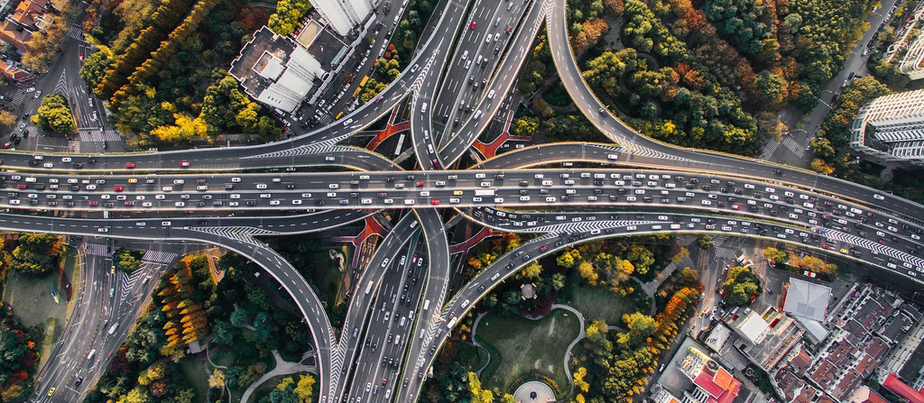

# Introduction and Purpose

Currently, the average US adult spends about three hours on a smart phone per day. This number has been increasing each year. With this large prevalence of smart phone technology on society, distracted driving is seemingly on the rise. Distracted driving due to smart phones can be categorized as texting, calling, internet surfing, or any other activity on the phone while driving. Furthermore, distraction from the primary task of driving occurs when drivers divert their attention from the driving task to some other activity.The purpose of this analysis is to use descriptive and inferential statistics to describe, calculate, and illustrate the impacts of hand held regulations during driving.

# Research Questions

# Data

The datasets to be used are downloaded from The Fatality Analysis Reporting System (FARS) website. FARS is a nationwide census providing NHTSA, Congress and the American public yearly data regarding fatal injuries suffered in motor vehicle traffic crashes. Starting in 2010, FARS began implementing a system to report on distracted driving. The columns included in each distracted dataset are STATE, ST_CASE, VEH_NO, and MDRDSTRD. The column of interest is MDRDSTRD which categorizes the type of distraction, if any. The number 0 indicates not distracted while all other numbers indicate some type of distraction attribute.

### Possible Constraints

The Fatality Analysis Reporting System (FARS) did not begin the implementation of documenting distracted driving until 2010. This limits our analysis to only years between 2010 and present.  
Although all states have some sort of regulation on cell phone use while driving, we will categorize regulations in two ways; 1) States that do regulate (states that prohibit all drivers from using hand-held cell phones while driving) and 2) States that do not regulate (All others).

# Setup

The majority of work can be done using Base-R. Other libraries will be added for data manipulation and visualization. Data manipulation is needed for data exploration and will include the dplyr and tidyverse libraries. Data visualization is needed to gain insights from the data that would not otherwise have been clear using other tools. These libraries include ggplot2 and RColorBrewer. ggplot2 is a powerful graphics language for creating elegant and complex plots. The idea is to provide the data and tell the function how to map variables to the aesthetics.

```r
# For Data Manipulation
# install.packages("dplyr")
library(dplyr)
library(tidyverse)
library(magrittr)

# For Data Visualization
# install.packages("ggplot2")
library(ggplot2)
library(RColorBrewer)
library(knitr)


# Import Distracted Datasets
distracted_2010 <- read.csv("data/FARS2010NationalCSV/DISTRACT.CSV")
distracted_2011 <- read.csv("data/FARS2011NationalCSV/DISTRACT.CSV")
distracted_2012 <- read.csv("data/FARS2012NationalCSV/DISTRACT.CSV")
distracted_2013 <- read.csv("data/FARS2013NationalCSV/DISTRACT.CSV")
distracted_2014 <- read.csv("data/FARS2014NationalCSV/DISTRACT.CSV")
distracted_2015 <- read.csv("data/FARS2015NationalCSV/DISTRACT.CSV")
distracted_2016 <- read.csv("data/FARS2016NationalCSV/DISTRACT.CSV")
distracted_2017 <- read.csv("data/FARS2017NationalCSV/DISTRACT.CSV")
distracted_2018 <- read.csv("data/FARS2018NationalCSV/DISTRACT.CSV")
```